# CUNY SPS MSDS D607 Project 1

Keith Colella

2023-02-19

## Task

In this project, you’re given a text file with chess tournament results where the information has some structure. Your job is to create an R Markdown file that generates a .CSV file (that could for example be imported into a SQL database) with the following information for all of the players:

Player’s Name, Player’s State, Total Number of Points, Player’s Pre-Rating, and Average Pre Chess Rating of Opponents

A sample of the .txt format is provided below.

```r
# ----------------------------------------------------------------------------------------- #
#     1 | GARY HUA                        |6.0  |W  39|W  21|W  18|W  14|W   7|D  12|D   4| #
#    ON | 15445895 / R: 1794   ->1817     |N:2  |W    |B    |W    |B    |W    |B    |W    | #
# ----------------------------------------------------------------------------------------- #
```

## Constructing a .CSV

First, we read in the data. The .txt file is captured as a single character string.

```r
txt <- read_file(paste0('https://raw.githubusercontent.com/kac624/',
                        'cuny/main/D607/data/tournamentinfo.txt'))
```

Next, we perform set-up before parsing the .txt file. This includes (i) removing line breaks from the character string, (ii) capturing the locations of long strings of dashes (“-”) that separate entries for different players, and (iii) setting up an empty dataframe that will hold our target variables.

```r
txt2 <- str_replace_all(txt, c('\n'=''))

locations <- str_locate_all(txt2, paste(replicate(89, "-"),
                                       collapse = "")
                            )[[1]]

df <- data.frame(matrix(ncol = 11, nrow = 0))
x <- c('name', 'state', 'total_pts', 'pre_rating', 'oppnt1',
       'oppnt2', 'oppnt3', 'oppnt4', 'oppnt5', 'oppnt6', 'oppnt7')
colnames(df) <- x
```

The following loop parses the data using the str_match function and regular expressions. The loop iterates on every “row” in the .txt file (based on previously identified locations), skipping the first row (which is a header).

1. All details for a single player are captured as a string, using the location of the long strings of dashes as start / end points.
2. The Player Name is extracted using an integer and “|” to identify the start, and another “|” and integer to signify the end.
3. The State is captured by matching a pattern of one space, two capital letters, a “|” and an integer.
4. Total Points are captured by looking for “|” following by an integer, a “.”, another integer and a closing “|”.
5. Pre-Rating is captured by matching intgers after “R:” and a “|”. The expression must account for the “R:” being following by either one or two spaces.
6. Finally, each Player’s list of opponents is captured by another loop that matches a “|”, followed by a capital letter, followed by spaces, followed by integers. The expression must account for blanks (two spaces). The loop looks for incrementally increasing numbers of matches to account for the seven rounds for each Player.

Finally, all these variables are moved into the previously created dataframe.

```r
for (i in 2:(nrow(locations) - 1)) {
  row <- str_sub(txt2, locations[i,2] + 1, locations[i+1,1] - 1)
  name <- trimws(str_match(row, '[0-9] \\| (.*?) \\|[0-9]')[,2])
  state <- str_match(row, ' ([A-Z]{2}) \\| [0-9]')[,2]
  total_pts <- str_match(row, '\\|([0-9]\\.[0-9])  \\|')[,2]
  pre_rating <- str_match(row, 'R:( |  )([0-9]+|[0-9]+P[0-9])')[,3]
  for (j in 1:7) {
    assign(paste0('oppnt', j),
           str_match(row, paste0('(\\|[A-Z]\\s+(  |[0-9]+)){',j,'}'))[,3])
  }
  df[i-1, ] <- c(name, state, total_pts, pre_rating, oppnt1,
                 oppnt2, oppnt3, oppnt4, oppnt5, oppnt6, oppnt7)
}
```

We still have one final variable to capture: Average Pre-Rating of Opponents. First, we convert the opponent player IDs to integers, so they can be used for indexing. Next, we loop through each row to calculate the average of all opponent player ratings, using the following steps.

1. The opponent IDs are captured in a single vector.
2. An empty ratings vector is created.
3. We use a second loop to iterate through each opponent player ID, using that ID as an index to grab the opponent player’s pre-rating from the previously created dataframe, and placing that rating into the ratings vector. The loop uses a conditional to skip rounds where a Player had no opponent.
4. The populated ratings vector is then averaged, and that value is added to a new column in the dataframe.

```r
for (i in colnames(df)[4:11]) {
  df[,i] <- as.integer(df[,i])
}

for (i in 1:nrow(df)) {
  oppnts <- df[i,5:11]
  ratings <- c()
  for (j in 1:length(oppnts)) {
    if (!is.na(oppnts[[j]])) {
      ratings <- c(ratings, df[oppnts[[j]], 'pre_rating'])
    }
  }
  avg_oppnt_rtg <- mean(ratings)
  df[i, 'avg_oppnt_rtg'] <- avg_oppnt_rtg
}
```

The resulting dataframe is previewed below, and exported to .CSV.

```r
head(df)
```

```
##                  name state total_pts pre_rating oppnt1 oppnt2 oppnt3 oppnt4
## 1            GARY HUA    ON       6.0       1794     39     21     18     14
## 2     DAKSHESH DARURI    MI       6.0       1553     63     58      4     17
## 3        ADITYA BAJAJ    MI       6.0       1384      8     61     25     21
## 4 PATRICK H SCHILLING    MI       5.5       1716     23     28      2     26
## 5          HANSHI ZUO    MI       5.5       1655     45     37     12     13
## 6         HANSEN SONG    OH       5.0       1686     34     29     11     35
##   oppnt5 oppnt6 oppnt7 avg_oppnt_rtg
## 1      7     12      4      1605.286
## 2     16     20      7      1469.286
## 3     11     13     12      1563.571
## 4      5     19      1      1573.571
## 5      4     14     17      1500.857
## 6     10     27     21      1518.714
```

```r
write_csv(df, 'output/proj1_chessRatings.csv')
```

## Analysis

I’ve constructed four plots below to assess the relationship between players’ ratings and their performance. Performance is measured in all cases by ‘Total Points’ they obtained during the tournament. The plots compare Total Points to (i) pre-rating, (ii) the difference between pre-rating and average opponent pre-rating, (iii) the sum of differences between pre-rating and each opponent’s pre-rating, and (iv) the number of matches in which they had a higher pre-rating than their opponent.

Unfortunately, none of these views provide evidence of a very clear relationship. All tend to point to a positive relationship between pre-rating and performance, as one might expect. But there appears to be a lot of noise in each plot, indicating that these relationships are not very strong.

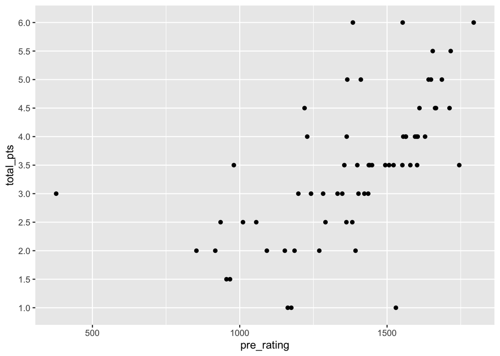

```r
ggplot(df, aes(x = pre_rating, y = total_pts)) +
  geom_point()
```

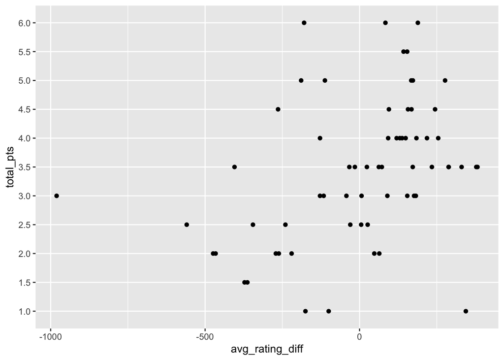

```r
df <- df %>%
  mutate(avg_rating_diff = pre_rating - avg_oppnt_rtg)

ggplot(df, aes(x = avg_rating_diff, y = total_pts)) +
  geom_point()
```

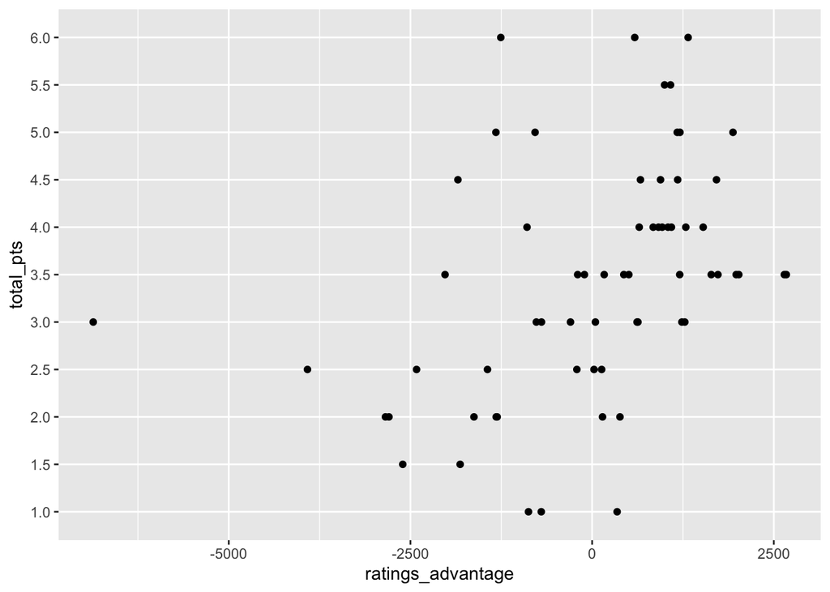

```r
for (i in 1:nrow(df)) {
  oppnts <- df[i,5:11]
  ratings <- c()
  for (j in 1:length(oppnts)) {
    if (!is.na(oppnts[[j]])) {
      ratings <- c(ratings, df[oppnts[[j]], 'pre_rating'])
    }
  }
  ratings_compare <- df[i,'pre_rating'] - ratings
  df[i, 'ratings_advantage'] <- sum(ratings_compare)
  df[i, 'advantaged_matches'] <- length(ratings_compare[ratings_compare>0])
}

ggplot(df, aes(x = ratings_advantage, y = total_pts)) +
  geom_point()
```

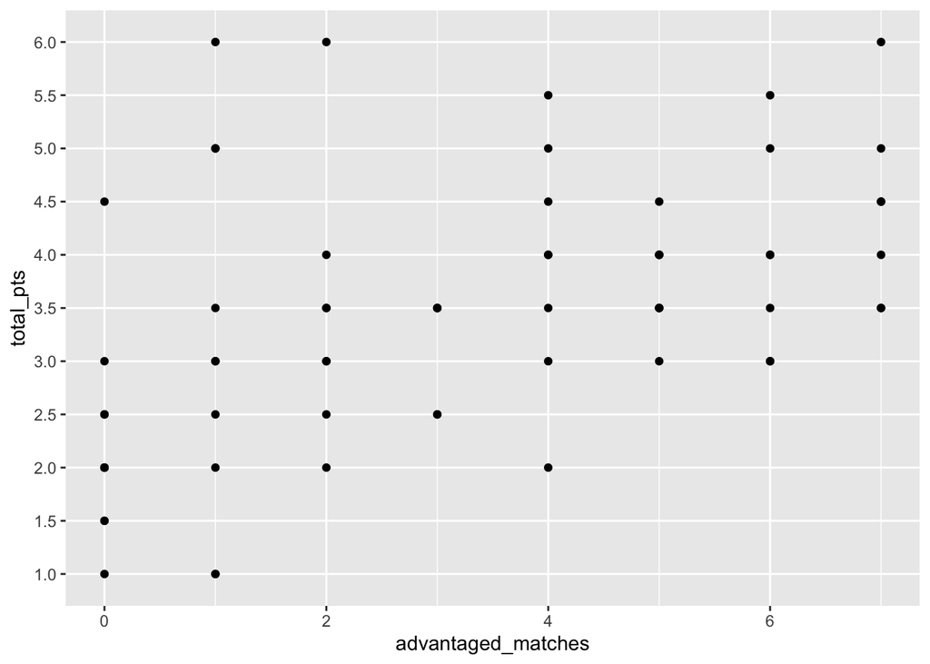

```r
ggplot(df, aes(x = advantaged_matches, y = total_pts)) +
  geom_point()
```